# Google Play Store App Data and How To Use It

## Why Google Play Store App Data?

As the mobile world becomes increasingly prevalent in every day lives, it’s important to understand the marketplace in which these apps are sold. It’s important to understand not only for the developers of these apps and how to appeal to the market but it’s also important for the consumer, understanding what is popular and why certain apps are popular. Today, I will be walking you through some basic Google Play Store Data and the many things you can do with it.

## Data Acquisition

Welcome ladies and gentlemen, to the tutorial that will make the rest of your life feel underwhelming. Today, we will be looking at google play store data, how to acquire it, how to parse it, and the many applications we can get from it. To start off, we’re going to need the actual data. I’m using a csv file which stands for “comma separated file” and that is simply a file structure that contains my data. If you want to follow along you can get the same data from [here](https://www.kaggle.com/lava18/google-play-store-apps)

```r
#importing all of the libraries I will need, tidyverse and readr for basic functions involving data frames, ggplot2 for graphical methods and broom for statstical methods
library(tidyverse)
library(ggplot2)
library(broom)
library(readr)

#reading the csv into a variable
main_data <- read_csv("googleplaystore.csv")
```

Once we’ve stored the data in a variable name, we’re going to view the data to see what we are working with. I’ve used the head and tail method in order to view both ends of my data. I’m also going to clean up the names of certain variables so that they are easier to use later on.

```r
names(main_data)[1] <- "title"
names(main_data)[9] <- "content_rating"
names(main_data)[11] <- "last_updated"
names(main_data)[12] <- "curr_ver"
names(main_data)[13] <- "and_ver"

#head displays the first few data entries
head(main_data)
```

```
## # A tibble: 6 x 13
##   title Category Rating Reviews Size  Installs Type  Price content_rating
##   <chr> <chr>     <dbl>   <dbl> <chr> <chr>    <chr> <chr> <chr>
## 1 Phot… ART_AND…    4.1     159 19M   10,000+  Free  0     Everyone
## 2 Colo… ART_AND…    3.9     967 14M   500,000+ Free  0     Everyone
## 3 U La… ART_AND…    4.7   87510 8.7M  5,000,0… Free  0     Everyone
## 4 Sket… ART_AND…    4.5  215644 25M   50,000,… Free  0     Teen
## 5 Pixe… ART_AND…    4.3     967 2.8M  100,000+ Free  0     Everyone
## 6 Pape… ART_AND…    4.4     167 5.6M  50,000+  Free  0     Everyone
## # … with 4 more variables: Genres <chr>, last_updated <chr>,
## #   curr_ver <chr>, and_ver <chr>
```

```r
#tail displays the last few data entries
tail(main_data)
```

```
## # A tibble: 6 x 13
##   title Category Rating Reviews Size  Installs Type  Price content_rating
##   <chr> <chr>     <dbl>   <dbl> <chr> <chr>    <chr> <chr> <chr>
## 1 FR F… BUSINESS  NaN         0 9.6M  10+      Free  0     Everyone
## 2 Sya9… FAMILY      4.5      38 53M   5,000+   Free  0     Everyone
## 3 Fr. … FAMILY      5         4 3.6M  100+     Free  0     Everyone
## 4 Park… MEDICAL   NaN         3 9.5M  1,000+   Free  0     Everyone
## 5 The … BOOKS_A…    4.5     114 Vari… 1,000+   Free  0     Mature 17+
## 6 iHor… LIFESTY…    4.5  398307 19M   10,000,… Free  0     Everyone
## # … with 4 more variables: Genres <chr>, last_updated <chr>,
## #   curr_ver <chr>, and_ver <chr>
```

If your data doesn’t come in the form of a csv, check out this [tutorial](https://www.kaggle.com/rtatman/manipulating-data-with-the-tidyverse) on Kaggle

# Data Cleaning And Parsing

We can see that we have a lot categories from our data. In order, we have our App (our title), the category the app belongs to, the current rating, the number of reviews, the size of the app, the number of installs, whether it is a paid or free app, the price (0 if free), the content rating, the genre the app falls into, the last updated date, the current version of the app and the android version of the app. Right off the bat, we can see that we’re going to run into some trouble with the current data. For example, if we wanted to analyze how many installs an app has, we’re going to need the installs column to function as a number. However, currently the Installs column functions as a series of characters because of the “+” appended to the end of it. Let’s convert the column into a double value by first removing the “+” and the commas at the end of and within each entry and converting the type of the column into a double.

```r
#removes the + from each entry
main_data$Installs = gsub("\\+","",main_data$Installs)

#converts each entry into a numeric variable rather than a character variable
main_data$Installs = as.numeric(gsub("\\,","",main_data$Installs))
head(main_data)
```

```
## # A tibble: 6 x 13
##   title Category Rating Reviews Size  Installs Type  Price content_rating
##   <chr> <chr>     <dbl>   <dbl> <chr>    <dbl> <chr> <chr> <chr>
## 1 Phot… ART_AND…    4.1     159 19M      10000 Free  0     Everyone
## 2 Colo… ART_AND…    3.9     967 14M     500000 Free  0     Everyone
## 3 U La… ART_AND…    4.7   87510 8.7M   5000000 Free  0     Everyone
## 4 Sket… ART_AND…    4.5  215644 25M   50000000 Free  0     Teen
## 5 Pixe… ART_AND…    4.3     967 2.8M    100000 Free  0     Everyone
## 6 Pape… ART_AND…    4.4     167 5.6M     50000 Free  0     Everyone
## # … with 4 more variables: Genres <chr>, last_updated <chr>,
## #   curr_ver <chr>, and_ver <chr>
```

```r
#Removes extra characters from the price and converts it into a numeric variable, then divides by 100 in order to make it in dollars
main_data$Price = gsub("\\.","",main_data$Price)
main_data$Price = as.numeric(gsub("\\$","",main_data$Price))
main_data <- main_data %>%
  mutate(Price=Price/100)
#Converts the last_updated column into a datetime object
main_data <- main_data %>%
  type_convert(col_types=cols(last_updated=col_datetime(format="%B %d, %Y")))
main_data$Genres = NULL
#Converts the size column to a numeric variable
main_data$Size = gsub("M","",main_data$Size)
main_data$Size = as.numeric(gsub("Varies with device","0",main_data$Size))
#Converts any NA's in Rating to 0
main_data %>%
  replace_na(list(Rating=0))
```

```
## # A tibble: 10,841 x 12
##    title Category Rating Reviews  Size Installs Type  Price content_rating
##    <chr> <chr>     <dbl>   <dbl> <dbl>    <dbl> <chr> <dbl> <chr>
##  1 Phot… ART_AND…    4.1     159  19      10000 Free      0 Everyone
##  2 Colo… ART_AND…    3.9     967  14     500000 Free      0 Everyone
##  3 U La… ART_AND…    4.7   87510   8.7  5000000 Free      0 Everyone
##  4 Sket… ART_AND…    4.5  215644  25   50000000 Free      0 Teen
##  5 Pixe… ART_AND…    4.3     967   2.8   100000 Free      0 Everyone
##  6 Pape… ART_AND…    4.4     167   5.6    50000 Free      0 Everyone
##  7 Smok… ART_AND…    3.8     178  19      50000 Free      0 Everyone
##  8 Infi… ART_AND…    4.1   36815  29    1000000 Free      0 Everyone
##  9 Gard… ART_AND…    4.4   13791  33    1000000 Free      0 Everyone
## 10 Kids… ART_AND…    4.7     121   3.1    10000 Free      0 Everyone
## # … with 10,831 more rows, and 3 more variables: last_updated <dttm>,
## #   curr_ver <chr>, and_ver <chr>
```

```r
#Creates a year column from the datetime variable and creates a periods variable that segments the data into 5 equally sized time periods
main_data <- main_data %>%
  mutate(year=strftime(last_updated,"%Y"))
main_data$year = as.numeric(main_data$year)
main_data <- main_data %>%
  mutate(periods=cut(year,breaks=5))
```

# Exploratory Data Analysis

Now that our data is fully prepared, it’s time to see what information we can collect. For the purposes of this tutorial, let’s go over some basic functions in R. In R, we have a method called filter which will filter out entries based on a condition. So, for example, we want to find the really popular apps and our definition of popular is an app that gains more than 1,000,000 downloads. Well, with our already clean data, we can acquire that information like this. In addition, let’s make a modification in our main table to identify which apps are popular. We can even determine which app is the most popular by arranging the apps in descending order based on installs.

```r
#creates an attribute to see if the app is popular and then creates a separate table with only the popular apps
main_data <- main_data %>%
  mutate(is_popular=ifelse(Installs < 1000000,FALSE,TRUE))
popular_apps <- filter(main_data,Installs > 1000000) %>%
  arrange(desc(Installs))
popular_apps
```

```
## # A tibble: 2,832 x 15
##    title Category Rating Reviews  Size Installs Type  Price content_rating
##    <chr> <chr>     <dbl>   <dbl> <dbl>    <dbl> <chr> <dbl> <chr>
##  1 Goog… BOOKS_A…    3.9  1.43e6     0   1.00e9 Free      0 Teen
##  2 Mess… COMMUNI…    4    5.66e7     0   1.00e9 Free      0 Everyone
##  3 What… COMMUNI…    4.4  6.91e7     0   1.00e9 Free      0 Everyone
##  4 Goog… COMMUNI…    4.3  9.64e6     0   1.00e9 Free      0 Everyone
##  5 Gmail COMMUNI…    4.3  4.60e6     0   1.00e9 Free      0 Everyone
##  6 Hang… COMMUNI…    4    3.42e6     0   1.00e9 Free      0 Everyone
##  7 What… COMMUNI…    4.4  6.91e7     0   1.00e9 Free      0 Everyone
##  8 Mess… COMMUNI…    4    5.66e7     0   1.00e9 Free      0 Everyone
##  9 Hang… COMMUNI…    4    3.42e6     0   1.00e9 Free      0 Everyone
## 10 Skyp… COMMUNI…    4.1  1.05e7     0   1.00e9 Free      0 Everyone
## # … with 2,822 more rows, and 6 more variables: last_updated <dttm>,
## #   curr_ver <chr>, and_ver <chr>, year <dbl>, periods <fct>,
## #   is_popular <lgl>
```

Wow, truly an incredible feat of technology. However, we can go one step further and try and see some summary stats. We can do this by grouping these apps by their category. So for this example, to keep the numbers simple, we’ll be using the table we just created of all the popular apps. Let’s see, we’ll do total number of installs, total number of reviews, ratio of installs to reviews, and average rating. We’re doing everything so try and keep up.

```r
#Summarizes total installs, ratio of installs to review, total reviews, and average ratings by category
popular_apps %>%
  group_by(Category) %>%
  summarize(total_installs=sum(Installs)
            ,total_review=sum(Reviews),
            ratio_install_to_review=total_installs/total_review,
            average_rating=mean(Rating)) %>%
  arrange(desc(total_installs))
```

```
## # A tibble: 33 x 5
##    Category    total_installs total_review ratio_install_to… average_rating
##    <chr>                <dbl>        <dbl>             <dbl>          <dbl>
##  1 GAME           34875000000   1576292417              22.1           4.39
##  2 COMMUNICAT…    32595000000    813582106              40.1           4.28
##  3 PRODUCTIVI…    14105000000    111662753             126.            4.34
##  4 SOCIAL         14025000000    619786958              22.6           4.29
##  5 TOOLS          11325000000    270148590              41.9           4.26
##  6 PHOTOGRAPHY    10025000000    211860819              47.3           4.33
##  7 FAMILY          9895000000    397935606              24.9           4.27
##  8 NEWS_AND_M…     7435000000     52348703             142.            4.22
##  9 TRAVEL_AND…     6820000000     61684951             111.            4.23
## 10 VIDEO_PLAY…     6185000000    109732749              56.4           4.29
## # … with 23 more rows
```

Another useful method is the select method which allows us to select particular attributes from tables. For example, if we wanted to streamline our data processing by only looking at the attributes that we will be using, we can use the select function.

```r
#demonstrates the usefulness of select by only selecting particular attributes
useful_att <- main_data %>%
  select("title","Installs","Category","last_updated","Size")
useful_att
```

```
## # A tibble: 10,841 x 5
##    title                      Installs Category   last_updated         Size
##    <chr>                         <dbl> <chr>      <dttm>              <dbl>
##  1 Photo Editor & Candy Came…    10000 ART_AND_D… 2018-01-07 00:00:00  19
##  2 Coloring book moana          500000 ART_AND_D… 2018-01-15 00:00:00  14
##  3 U Launcher Lite – FREE Li…  5000000 ART_AND_D… 2018-08-01 00:00:00   8.7
##  4 Sketch - Draw & Paint      50000000 ART_AND_D… 2018-06-08 00:00:00  25
##  5 Pixel Draw - Number Art C…   100000 ART_AND_D… 2018-06-20 00:00:00   2.8
##  6 Paper flowers instructions    50000 ART_AND_D… 2017-03-26 00:00:00   5.6
##  7 Smoke Effect Photo Maker …    50000 ART_AND_D… 2018-04-26 00:00:00  19
##  8 Infinite Painter            1000000 ART_AND_D… 2018-06-14 00:00:00  29
##  9 Garden Coloring Book        1000000 ART_AND_D… 2017-09-20 00:00:00  33
## 10 Kids Paint Free - Drawing…    10000 ART_AND_D… 2018-07-03 00:00:00   3.1
## # … with 10,831 more rows
```

With these tools, we can gather important information like summary statistics by category.

```r
#getting the summary statistics for th epopular apps
most_pop <- popular_apps %>%
  group_by(Category) %>%
  summarize(min=min(Installs),
            max=max(Installs),
            mean=mean(Installs))
most_pop
```

```
## # A tibble: 33 x 4
##    Category                min        max       mean
##    <chr>                 <dbl>      <dbl>      <dbl>
##  1 ART_AND_DESIGN      5000000   50000000  12777778.
##  2 AUTO_AND_VEHICLES   5000000   10000000   7000000
##  3 BEAUTY              5000000   10000000   7500000
##  4 BOOKS_AND_REFERENCE 5000000 1000000000  46097561.
##  5 BUSINESS            5000000  100000000  18529412.
##  6 COMICS              5000000   10000000   6666667.
##  7 COMMUNICATION       5000000 1000000000 195179641.
##  8 DATING              5000000   10000000   8269231.
##  9 EDUCATION           5000000  100000000  14464286.
## 10 ENTERTAINMENT       5000000 1000000000  34753086.
## # … with 23 more rows
```

For later, let’s get the top 10 most popular categories by average installs.

```r
#getting the summary statistics for the top 10 categories
ten_pop <- main_data %>%
  group_by(Category) %>%
  summarize(min=min(Installs),
            max=max(Installs),
            mean=mean(Installs)) %>%
  arrange(desc(mean)) %>%
  slice(1:10)
ten_pop
```

```
## # A tibble: 10 x 4
##    Category             min        max      mean
##    <chr>              <dbl>      <dbl>     <dbl>
##  1 COMMUNICATION          1 1000000000 84359887.
##  2 SOCIAL                 0 1000000000 47694467.
##  3 VIDEO_PLAYERS         10 1000000000 35554301.
##  4 PRODUCTIVITY           0 1000000000 33434178.
##  5 GAME                   1 1000000000 30669602.
##  6 PHOTOGRAPHY            5 1000000000 30114172.
##  7 TRAVEL_AND_LOCAL       0 1000000000 26623594.
##  8 NEWS_AND_MAGAZINES     0 1000000000 26488755.
##  9 ENTERTAINMENT      10000 1000000000 19256107.
## 10 TOOLS                  1 1000000000 13585732.
```

This gives me a wonderful idea to compare the aggregate data to the data of our most popular apps. Let’s get started.

```r
#Anti joining the data in order to get all of the remaining "unpopular" apps
unpopular_apps <- main_data %>%
  anti_join(popular_apps, by=c("title","Reviews","Installs"))

#getting stats for the popular apps
popular_app_stats <- popular_apps %>%
  summarize(total_installs=sum(Installs),total_review=sum(Reviews),
            ratio_install_to_review=total_installs/total_review,
            average_rating=mean(Rating),mean_installs=mean(Installs))
#getting stats for the unpopular apps
unpopular_app_stats <- unpopular_apps %>%
  summarize(total_installs=sum(Installs,na.rm=TRUE),
            total_review=sum(Reviews,na.rm=TRUE),
            ratio_install_to_review=total_installs/total_review,
            average_rating=mean(Rating,na.rm=TRUE),
            mean_installs=mean(Installs,na.rm=TRUE))
#combining the two to make viewing easier
combined = rbind(popular_app_stats,unpopular_app_stats)
combined
```

```
## # A tibble: 2 x 5
##   total_installs total_review ratio_install_t… average_rating mean_installs
##            <dbl>        <dbl>            <dbl>          <dbl>         <dbl>
## 1   165630000000   4752282912             34.9           4.31     58485169.
## 2     2003433487     62334481             32.1           4.14       250179.
```

## Graphing Data and Relationships

With the power of R, we can do anything graph related. We can even plot the relationship between any given variables. Let’s start with something simple. Graphing how many apps are in each category. For more information on the power of ggplot check out the documentation reference located [here](https://ggplot2.tidyverse.org/reference/)

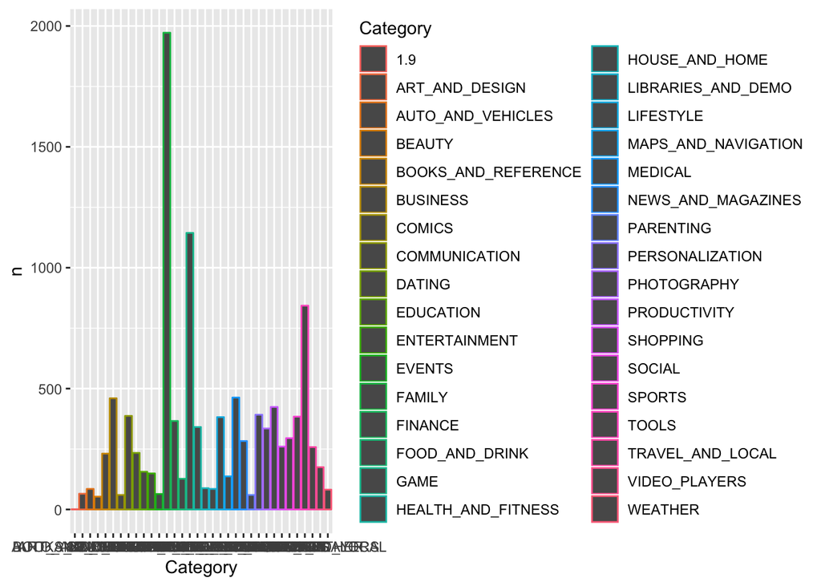

```r
#graphing how many apps are in each category
main_data %>%
  group_by(Category) %>%
  count() %>%
  ggplot(aes(x=Category,y=n,colour=Category)) + geom_bar(stat="identity")
```

The two largest categories in the center are family and games. But why is any of this important. Well knowing the distribution of the Google Play Store can help potential developers understand the market and target certain demographics.

Another fixed statistic that we can attempt to graph is the content rating distribution.

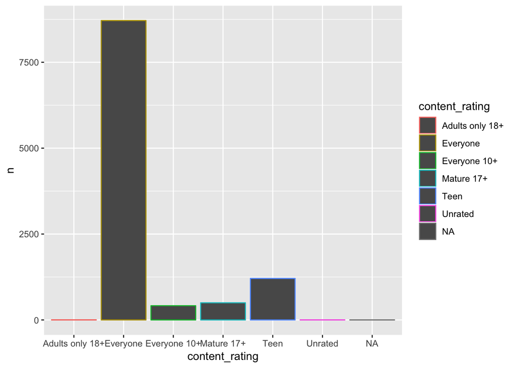

```r
#graphing how many apps per content rating
main_data %>%
  group_by(content_rating) %>%
  count() %>%
  ggplot(aes(x=content_rating,y=n,colour=content_rating)) + geom_bar(stat="identity")
```

And finally, we can visualize the portion of apps that are free and the portion of apps that aren’t free.

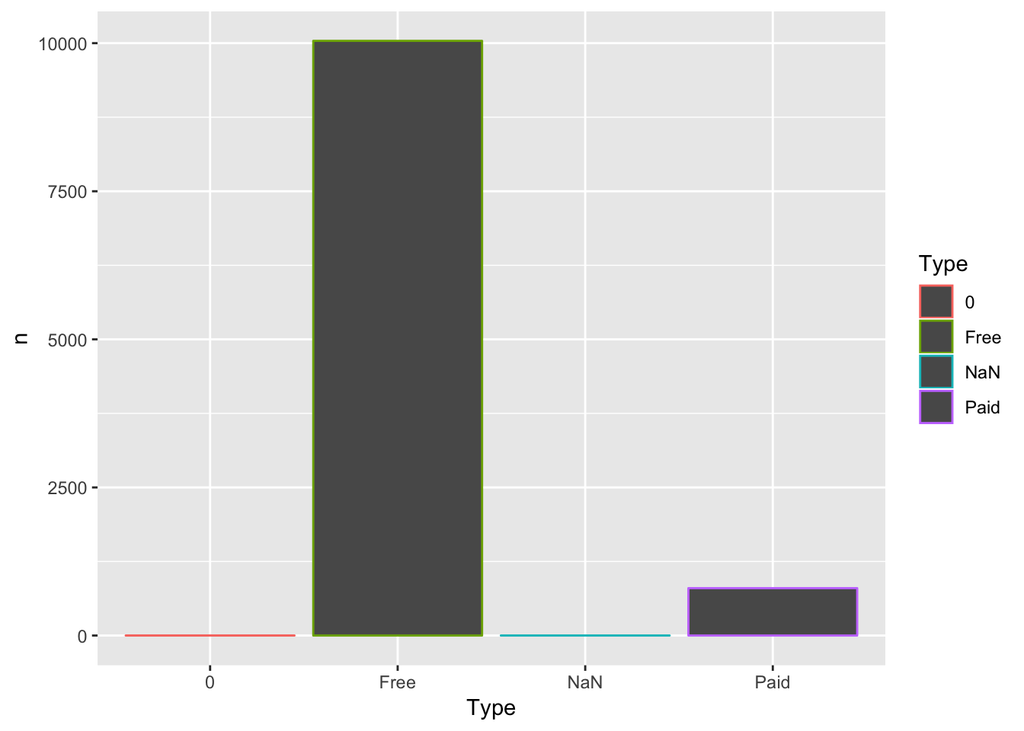

```r
#Graphing Type which is a discrete variable either free or paid
main_data %>%
  group_by(Type) %>%
  count() %>%
  ggplot(aes(x=Type,y=n,colour=Type)) + geom_bar(stat="identity")
```

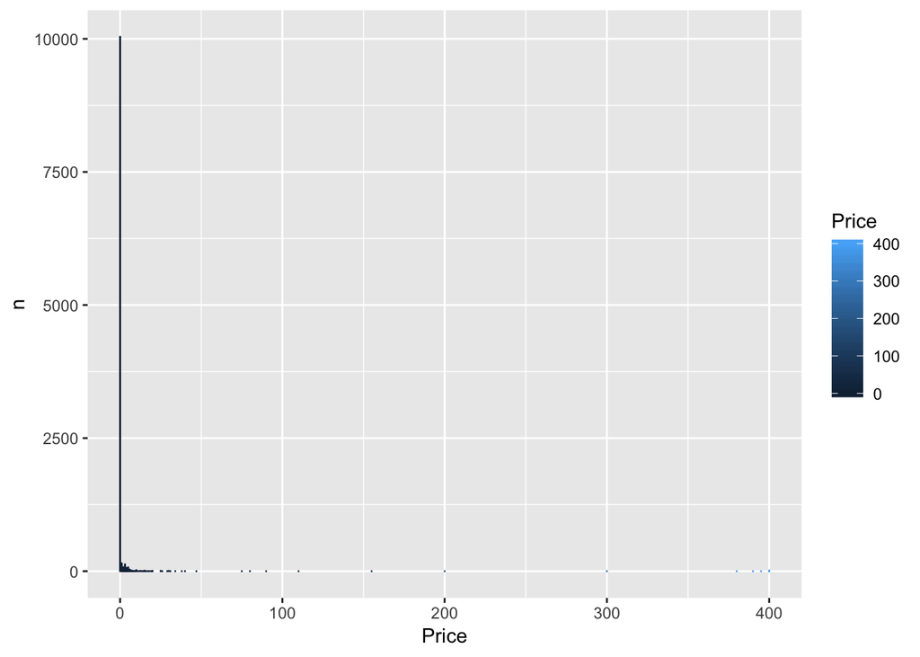

```r
#graphing price which is a continuous variable
main_data %>%
  group_by(Price) %>%
  count() %>%
  ggplot(aes(x=Price,y=n,colour=Price)) + geom_bar(stat="identity")
```

# Sub-Exploration: Price and Revenue

To start, with let’s get the top 10 most expensive apps and some preliminary information.

```r
#retrieving the most expensive apps
main_data %>%
  arrange(desc(Price)) %>%
  slice(1:10) %>%
  select(title,Category,Rating,Reviews,Size,Installs,Price)
```

```
## # A tibble: 10 x 7
##    title                       Category Rating Reviews  Size Installs Price
##    <chr>                       <chr>     <dbl>   <dbl> <dbl>    <dbl> <dbl>
##  1 I'm Rich - Trump Edition    LIFESTY…    3.6     275   7.3    10000  400
##  2 most expensive app (H)      FAMILY      4.3       6   1.5      100  400.
##  3 💎 I'm rich                 LIFESTY…    3.8     718  26      10000  400.
##  4 I am rich                   LIFESTY…    3.8    3547   1.8   100000  400.
##  5 I am Rich Plus              FAMILY      4       856   8.7    10000  400.
##  6 I Am Rich Premium           FINANCE     4.1    1867   4.7    50000  400.
##  7 I am Rich!                  FINANCE     3.8      93  22       1000  400.
##  8 I am rich(premium)          FINANCE     3.5     472  NA       5000  400.
##  9 I Am Rich Pro               FAMILY      4.4     201   2.7     5000  400.
## 10 I am rich (Most expensive … FINANCE     4.1     129   2.7     1000  400.
```

We can clearly observe that these apps all have a common theme to them. But in order to get a better sense of how much money these apps have made, let’s create another column in order to determine the revenue of all of the paid apps.

```r
#creating a revenue variable
paid_apps <- main_data %>%
  filter(Type=="Paid") %>%
  mutate(revenue=Installs*Price) %>%
  arrange(desc(revenue))
paid_apps
```

```
## # A tibble: 800 x 16
##    title Category Rating Reviews  Size Installs Type   Price content_rating
##    <chr> <chr>     <dbl>   <dbl> <dbl>    <dbl> <chr>  <dbl> <chr>
##  1 Mine… FAMILY      4.5 2376564   0   10000000 Paid    6.99 Everyone 10+
##  2 Mine… FAMILY      4.5 2375336   0   10000000 Paid    6.99 Everyone 10+
##  3 I am… LIFESTY…    3.8    3547   1.8   100000 Paid  400.   Everyone
##  4 I Am… FINANCE     4.1    1867   4.7    50000 Paid  400.   Everyone
##  5 Hitm… GAME        4.6  408292  29   10000000 Paid    0.99 Mature 17+
##  6 Gran… GAME        4.4  348962  26    1000000 Paid    6.99 Mature 17+
##  7 Face… PHOTOGR…    4.4   49553  48    1000000 Paid    5.99 Everyone
##  8 Face… PHOTOGR…    4.4   49553  48    1000000 Paid    5.99 Everyone
##  9 Face… PHOTOGR…    4.4   49553  48    1000000 Paid    5.99 Everyone
## 10 Slee… LIFESTY…    4.5   23966  NA    1000000 Paid    5.99 Everyone
## # … with 790 more rows, and 7 more variables: last_updated <dttm>,
## #   curr_ver <chr>, and_ver <chr>, year <dbl>, periods <fct>,
## #   is_popular <lgl>, revenue <dbl>
```

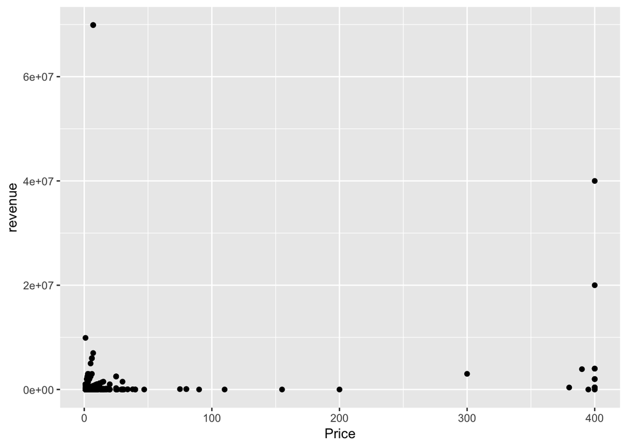

```r
#plotting it out
paid_apps %>%
  group_by(Category) %>%
  ggplot(aes(x=Price,y=revenue)) + geom_point()
```

The relationship between price and revenue appears to be bimodal which indicates that if you really want a large revenue based solely on the price of your app, you should aim for pricing your app either very low or very high.

# Graphing Other Relationships

We can start with the relationship between Installs and Size.

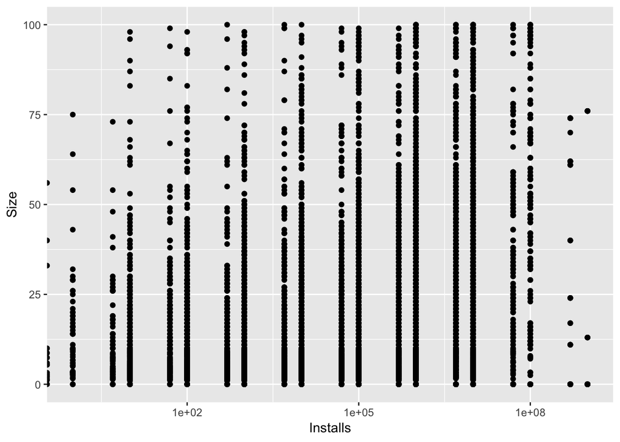

```r
#plotting Installs to Size relationship
main_data %>%
  ggplot(aes(x=Installs,y=Size)) + geom_point() + scale_x_log10()
```

To nobodies surprise, it doesn’t seem that there is a relationship between how large an app is and how many installs it receives. Even at the extreme end of installs, the size of an app does not seem to dictate how popular it will be.

One of the questions, I’ve always wanted to learn was the relationship between installs and rating. For an app, the number of installs is one of the main metrics used to determine success. Rating, is another one of those metrics. In order to see the relationship between these two variables let’s plot them. I also scaled the x axis logarithmically in order to make the data easier to visualize. To understand why I used a logarithmic scale, check out this link [here](http://onlinestatbook.com/2/transformations/log.html)

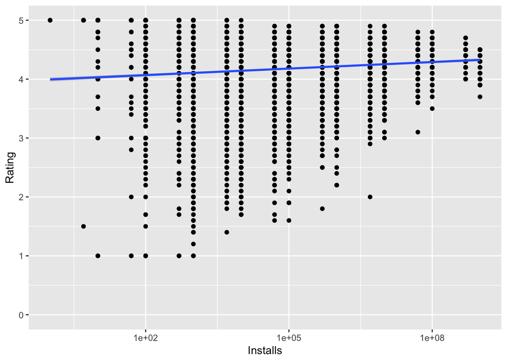

```r
#Plotting relationship to Installs with a linear regression
main_data %>%
  ggplot(aes(x=Installs,y=Rating)) + geom_point() + ylim(0,5) + geom_smooth(method=lm) + scale_x_log10()
```

Due to the discrete nature of our install column, our graph looks like this. Our linear regression model also appears to be relatively flat indicating that there is almost no relationship between the two variables. Let’s look at another relationship, the relationship between last updated and installs. This time, we will separate based on popularity and apply a linear regression.

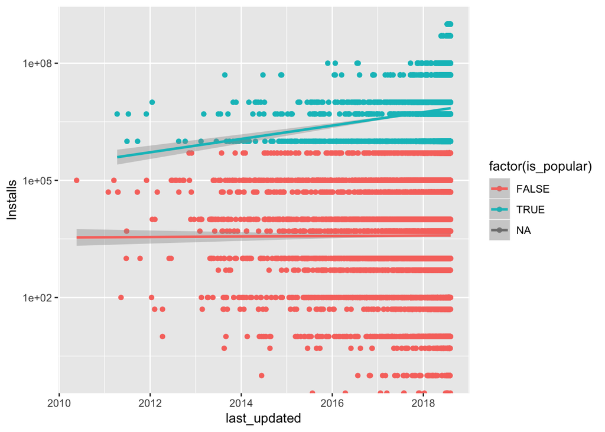

```r
#Plotting last updated to installs and differentiating based on popularity
main_data %>%
  ggplot(aes(x=last_updated,y=Installs,group=factor(is_popular),colour=factor(is_popular))) + geom_point() + geom_smooth(method=lm) + scale_y_log10()
```

As we can see, the popular apps have a slightly upward trend when it comes to the linear regression. This makes sense as we can expect apps that are popular to be updated more recently than all other apps. But how much? Let’s take a look at the exact numbers and see what we can gather. To understand what a linear regression is, check out this [link](https://en.wikipedia.org/wiki/Linear_regression)

```r
#getting statistics on the linear regression model
pop_linear <- lm(Installs~last_updated,data=popular_apps)
pop_linear
```

```
##
## Call:
## lm(formula = Installs ~ last_updated, data = popular_apps)
##
## Coefficients:
##  (Intercept)  last_updated
##   -1.063e+09     7.358e-01
```

```r
non_pop_linear <- lm(Installs~last_updated,data=unpopular_apps)
non_pop_linear
```

```
##
## Call:
## lm(formula = Installs ~ last_updated, data = unpopular_apps)
##
## Coefficients:
##  (Intercept)  last_updated
##   -2.224e+06     1.642e-03
```

Something else we can check is how the market changes over time. Earlier in this tutorial, we added a column called periods that separate the apps into 5 equally spaced out time periods. Let’s do the same graph we did before except separate it by periods.

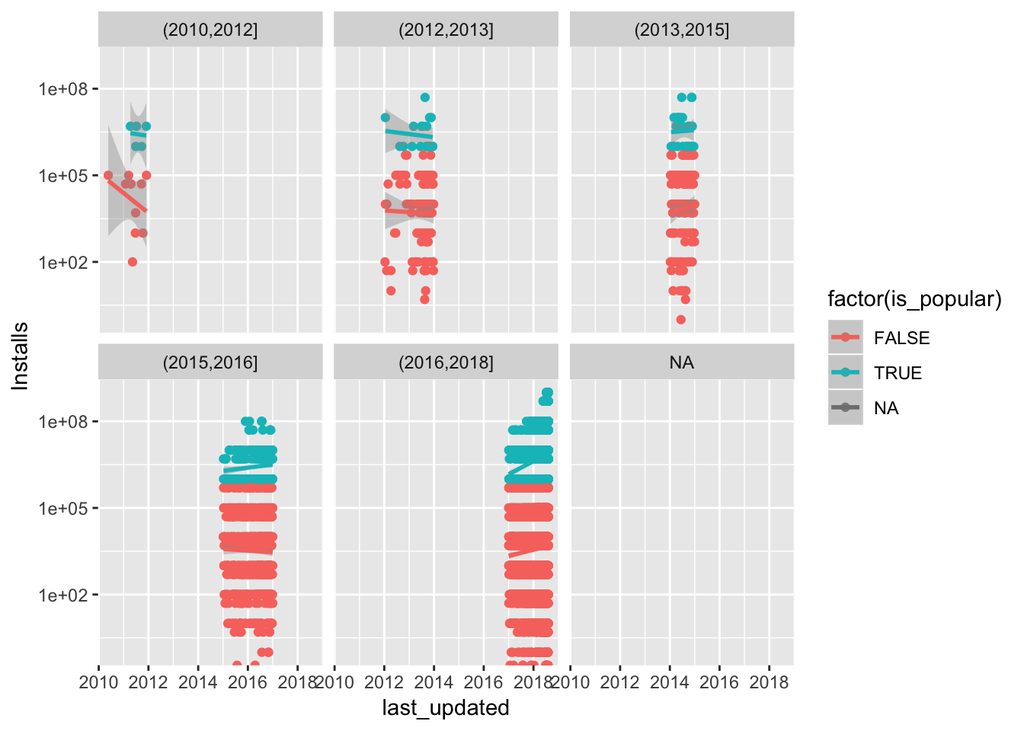

```r
#Graphing based on time periods
main_data %>%
  ggplot(aes(x=last_updated,y=Installs,group=factor(is_popular),colour=factor(is_popular))) + geom_point() + geom_smooth(method=lm) + scale_y_log10() + facet_wrap(~periods)
```

With this dataset, we can see that each period has a different concentration of apps and a different regression. The regression for the most recent period appears to be more positive relative to the rest of the time periods.

One additional thing that we can check however, is how other factors play into the success of an app. Last updated date is just one aspect that we can check however, I hypothesize that category can also play an important factor in determining how successful an app can be. In order to do that, we have to add an interaction term for category.

```r
#Using an analysis of variance to determine whether category can determine Installs
pop_interaction <- lm(Installs~last_updated*Category,data=popular_apps)
tidy(pop_interaction) %>%
  arrange(desc(estimate))
```

```
## # A tibble: 66 x 5
##    term                                estimate std.error statistic p.value
##    <chr>                                  <dbl>     <dbl>     <dbl>   <dbl>
##  1 CategoryPARENTING                    2.75e10   1.27e12    0.0217   0.983
##  2 (Intercept)                          2.02e 9   2.32e10    0.0870   0.931
##  3 last_updated:CategoryNEWS_AND_MAGA…  1.71e 1   1.67e 1    1.02     0.306
##  4 last_updated:CategorySHOPPING        5.40e 0   1.72e 1    0.313    0.754
##  5 last_updated:CategoryCOMMUNICATION   4.35e 0   1.51e 1    0.288    0.774
##  6 last_updated:CategoryHEALTH_AND_FI…  3.99e 0   1.68e 1    0.237    0.812
##  7 last_updated:CategoryPRODUCTIVITY    3.80e 0   1.51e 1    0.251    0.802
##  8 last_updated:CategorySOCIAL          3.58e 0   1.52e 1    0.236    0.813
##  9 last_updated:CategoryTRAVEL_AND_LO…  3.52e 0   1.52e 1    0.231    0.817
## 10 last_updated:CategoryVIDEO_PLAYERS   2.54e 0   1.51e 1    0.168    0.867
## # … with 56 more rows
```

```r
non_pop_interaction <- lm(Installs~last_updated*Category,data=unpopular_apps)
anova(pop_interaction)
```

```
## Analysis of Variance Table
##
## Response: Installs
##                         Df     Sum Sq    Mean Sq F value    Pr(>F)
## last_updated             1 6.9593e+17 6.9593e+17 30.0984 4.478e-08 ***
## Category                32 5.9375e+18 1.8555e+17  8.0248 < 2.2e-16 ***
## last_updated:Category   32 6.8165e+17 2.1302e+16  0.9213    0.5945
## Residuals             2766 6.3955e+19 2.3122e+16
## ---
## Signif. codes:  0 '***' 0.001 '**' 0.01 '*' 0.05 '.' 0.1 ' ' 1
```

```r
anova(non_pop_interaction)
```

```
## Analysis of Variance Table
##
## Response: Installs
##                         Df     Sum Sq    Mean Sq  F value    Pr(>F)
## last_updated             1 2.8653e+13 2.8653e+13 207.3399 < 2.2e-16 ***
## Category                32 8.3811e+13 2.6191e+12  18.9521 < 2.2e-16 ***
## last_updated:Category   32 1.5525e+13 4.8515e+11   3.5106 9.027e-11 ***
## Residuals             7942 1.0975e+15 1.3820e+11
## ---
## Signif. codes:  0 '***' 0.001 '**' 0.01 '*' 0.05 '.' 0.1 ' ' 1
```

I applied the ANOVA function which stands for the analysis of variance. It tests for statistical variance and you can learn more about it [here](https://en.wikipedia.org/wiki/Analysis_of_variance). For our statistical analysis, we mainly want to focus on the last column. The smaller the value, the higher the likelihood that our statistical model is likely. As we can see, with the non popular apps (9.027e-11), the interaction term is much more accurate in predicting total installs than with our popular group (0.5945). Let’s plot the residuals for this data set to see what we can find.

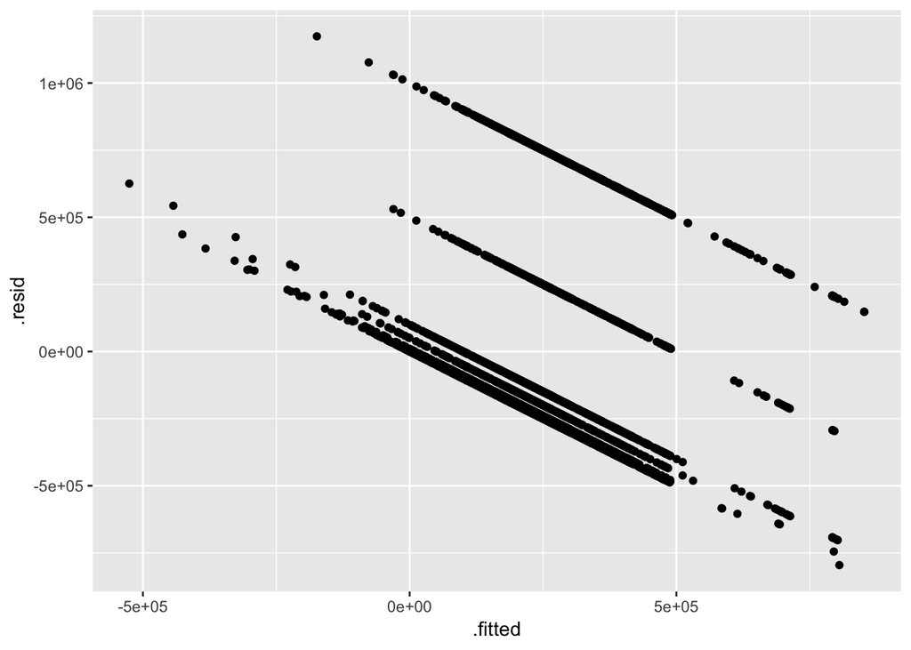

```r
#plotting fitted to residuals to see the relationship
non_pop_augment <- augment(non_pop_interaction) %>%
  ggplot(aes(x=.fitted, y=.resid)) + geom_point()
non_pop_augment
```

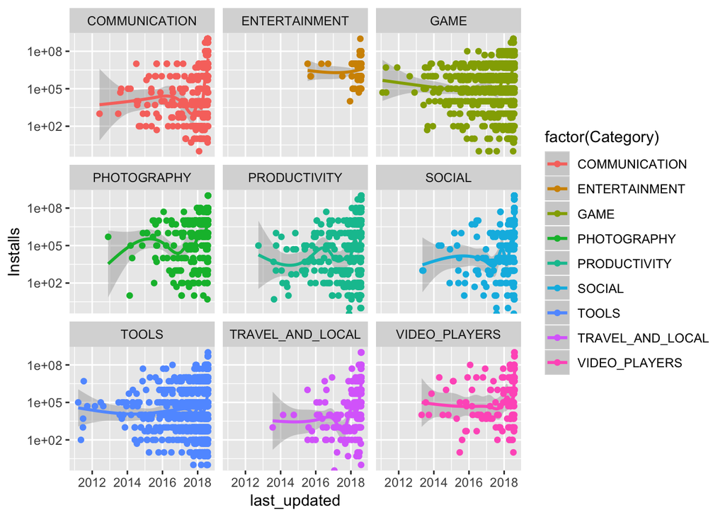

```r
#plotting based on category to see individual trends within categories
main_data %>%
  filter(Category %in% c("COMMUNICATION","SOCIAL","VIDEO_PLAYERS","VIDEO","PRODUCTIVITY","GAME","PHOTOGRAPHY","TRAVEL_AND_LOCAL","NEWS_AND_MAGAZINE","ENTERTAINMENT","TOOLS")) %>%
  ggplot(aes(x=last_updated,y=Installs,group=Category,colour=factor(Category)))  + geom_smooth() + geom_point() + scale_y_log10() + facet_wrap(~Category)
```